# Firm downsizing and satisfaction among United States and European customers

Converted from PDF `Lewin-DownsizingCustomerSatisfaction-2010-JBR.pdf` · 10 pages · anchors: page `#pN`, block `#pN-bK`

Page 1

### Firm downsizing and satisfaction among United States and European customers

### Jeffrey E. Lewin <sup>a</sup><sup>,</sup>⁎, Wim Biemans <sup>b</sup><sup>,</sup>⁎, Wolfgang Ulaga <sup>c</sup><sup>,</sup>⁎

a University of North Texas, Denton, TX 76203-1396, United States b University of Groningen, Groningen, The Netherlands c HEC School of Management, 1, rue de la Libération 78351 Jouy en Josas cedex Paris, France

#### a b s t r a c t a r t i c l e i n f o

Article history: Accepted 24 May 2009

Keywords: Value Satisfaction Loyalty Downsizing Cultural differences

This study examines the impact that downsizing of suppliers' sales and support personnel has on business customers' satisfaction. The study investigates what influence cultural differences may have on business customers' evaluations of satisfaction with and loyalty toward downsized suppliers. Survey data collected from 435 purchasing professionals in the United States, France, and The Netherlands provide answers to these research questions. Findings indicate that business customers are not satisfied with downsized suppliers' performance. However the results relating to cultural influence are mixed. This report suggests possibilities for future research efforts in this area.

© 2009 Elsevier Inc. All rights reserved.

1. Introduction

Customer satisfaction is an important source of competitive advantage (Rust et al., 2000), often leading to customer loyalty and repeat purchase (Bolton, 1998; Lam et al., 2004). Customer satisfaction significantly influences an organization's current and future performance (Anderson et al., 1994). Research in many free market economies throughout the world support this proposition (e.g., Liang and Wang, 2004; Wiele et al., 2002). Historically, the literature views product quality as the primary driver of customer satisfaction. However, in today's global economy, customers often perceive product quality among competitors as similar. As a result, customer satisfaction relates increasingly to the quality of the ancillary services that attach to a company's overall offering (Bolton et al., 2003; Wilson et al., 2001). Within this context, positive interactions with a firm's sales and customer service-support personnel are an important source of customer satisfaction (Ennew and Ahmed 1999; Gwinner et al., 1998; Heskett et al., 1994).

Thus, when a supplier eliminates sales and support personnel, as is often the case in downsized firms (Markels and Murray, 1996), the relationships between the supplier and its customers become vulnerable to customer defections (Bendapudi and Leone, 2002). Interestingly, the important relationship between customer satisfac-

tion and consistency in sales and support personnel is seemingly overlooked by organizations engaging in downsizing activities. Instead, these organizations focus on potential reductions in operating expenses, and expected improvements in market responsiveness. However, often unexpected costs are associated with downsizing. Among these costs is the inability to fully satisfy customer needs and the concomitant reduction in customer satisfaction (Fornell et al., 1996). While limited research, coupled with anecdotal accounts, provide some insight into the relationship between organizational downsizing and customer satisfaction in business-to-consumer markets (e.g., Bryant, 1997; Fornell et al., 1996), to date few studies have empirically examined these relationships in business-to-business markets. However, many believe that behavior among buyers in these two environments is significantly different; thus empirical findings from B2C research may not be readily applicable in B2B environments (Beverland et al., 2007; Doney and Cannon,1997; Edwards et al., 2007; Lam et al., 2004).

Further, the majority of extant downsizing studies focus on downsizing among U.S. organizations. However, downsizing initiatives spread well beyond the U.S. (examples offered in the following section). Additionally, in global business environments where cultural values and norms vary among customer groups, understanding how cultural differences affect perceptions of performance quality and satisfaction becomes crucial; especially with regard to how global suppliers allocate resources within diverse cultural regions (Laroche et al., 2004).

Given the above, this work makes several important contributions to the literature. First, adopting a model used primarily to examine customer satisfaction in B2C contexts (see Section 3.1), the adopted model is extended to an examination of customer satisfaction

Journal of Business Research 63 (2010) 697–706

⁎ Corresponding authors. Lewin, is to be contacted at Department of Marketing and Logistics, College of Business, University of North Texas, P. O. Box 311396, Denton, TX 76203-1396, United States. Biemans, University of Groningen, P.O. Box 72, 9700 AB, Groningen, The Netherlands. Ulaga, HEC School of Management, 1, rue de la Libération, 78351 Jouy en Josas, cedex Paris, France. E-mail addresses: Jeffrey.Lewin@unt.edu (J.E. Lewin), W.G.Biemans@rug.nl (W. Biemans), ulaga@hec.fr (W. Ulaga).

0148-2963/$ – see front matter © 2009 Elsevier Inc. All rights reserved. doi:10.1016/j.jbusres.2009.05.005

Contents lists available at ScienceDirect

## Journal of Business Research

Page 2

exclusively in B2B contexts. Second, the potential impact of supplier downsizing on business customer satisfaction and loyalty is investigated using a sample of professional purchasers drawn from both U.S. and European markets; expanding the investigation of supplier downsizing beyond U.S. borders. Third, the question of whether or not cultural differences influence expectations and evaluations of supplier performance, and subsequent business customer satisfaction and loyalty, is examined. Data collected from 435 purchasing professionals in the U.S., The Netherlands, and France is used to examine the research questions enumerated above.

The balance of this work is organized in the following manner. First, the proposed links between downsizing, culture, customer satisfaction, and loyalty are outlined and then the relevant extant literature is reviewed; forming the basis for the study hypotheses. Then, the research methodology is outlined; followed by a summary discussion of the findings, implications, limitations, and directions for future research.

2. Organizational downsizing and customer satisfaction

2.1. Organizational downsizing

Downsizing is commonplace in present-day industrialized markets (Nixon et al., 2004). Between 1995 and 2007, approximately 11.5 million people lost their jobs to downsizing in the U.S. alone. Further, according to U.S. Bureau of Labor Statistics data (2005), sales and marketing personnel have been hit harder than many other groups. Not only are reductions in work force size becoming more frequent (Burton et al., 2005), organizations' rationale for downsizing is changing as well (Hodson and Roscigno, 2004). In the past, layoffs were a last option used by managers confronted with plummeting firm performance. More recently, however, healthy firms around the world are using downsizing as a proactive management strategy in a continuous quest to reduce costs (Ferraro et al., 2005). For example, Citigroup announced plans to cut 5.2% of its work force (17,000 jobs) after enjoying revenue growth of 35% over the prior 5 years (CNNMoney.com, 2007). Similarly, Germany's Allianz AG announced plans to eliminate 9000 jobs in an effort to reduce costs (Veysey and Miller, 2006) after achieving increases in net income of 69% in 2005 and 79% in 2006. Additional examples include HP, Royal Dutch Shell, Bayer Schering, IBM, and Unilever.

In an effort to explain these seemingly contradictory patterns, some argue that three forces, coercive-, mimetic-, and normativeisomorphism, strongly influence managerial decisions related to corporate downsizing. Coercive isomorphism compels firms to conform to institutional norms that define legitimate structures and activities. Mimetic isomorphism impels organizations to mimic the actions of recognized industry leaders. Normative isomorphism– emerging through professional conferences, seminars and networks– pressures executives to adopt currently accepted management practices and philosophies (McKinley et al., 2000). As such, presentday downsizing decisions often are not so much related to economic considerations as they are related to socio-cognitive organizational schemas that view downsizing as effective, necessary, and inevitable— even if the consequences for the organization are uncertain (Lewin, 2001; Lewin and Johnston, 1996; McKinley et al., 2000). The anticipated positive effects of downsizing are decreasing labor costs indirectly leading to greater productivity, improvement in overall effectiveness, and increasing competitive advantage (Lewin, 2003). However, recent empirical findings indicate no significant differences in financial performance, over time, between firms that have downsized and firms that have not downsized (Cascio et al., 1997; De Meuse, et al., 2004; Nixon et al., 2004). On the other hand, the negative effects of downsizing are escalating employee workloads, decreasing employee morale, and decreases in an organization's

ability to learn and adapt (De Meuse et al., 2004; Mishra and Spreitzer, 1998).

2.2. Organizational downsizing and customer satisfaction

Common strategies for enhancing organizational performance include increasing customer satisfaction and improving system productivity (Anderson et al., 1997; Homburg and Rudolph, 2001). Methods for improving productivity include automation of processes, substituting capital for labor, and more recently, reductions in work force size with the expectation that the remaining employee base will make up the shortfall (Brockner, 1988; Oliva and Sterman, 2001).

Organizations often attempt to enhance overall performance by achieving gains in both productivity and customer satisfaction simultaneously. However, in some situations these two goals are incompatible. For example, when labor costs are reduced through downsizing, the result may be a relatively immediate gain in productivity. However, long-term firm performance likely will be at risk when customer satisfaction is dependent on the efforts of customer service-support personnel. When this is the case, significant tradeoffs may exist between productivity and customer satisfaction (Bendapudi and Leone, 2002; Estelami and Hurley, 2003; Kamakura et al., 2002; Nixon et al., 2004).

2.3. The potential influence of culture

Companies recognize that customer satisfaction and loyalty are critical to their long-term success. However, achieving these goals is especially difficult in diverse international settings where many of the causes of customer (dis)satisfaction vary according to cultural context (Bolten and Myers, 2006; Laroche et al., 2004). Two complimentary views on national culture (Hall, 1976; Hofstede, 1980) often are applied to the examination of a variety of multi-cultural business topics (e.g., Bolton and Myers, 2006; Laroche et al., 2004; Scheer et al., 2003). In the first, Hall (1976) posits that cultures vary on a context continuum. In lower-context cultures personal achievement and welfare are of prime importance. In these cultures greater emphasis is placed on discrete encounters, with little regard for long-term commitment and loyalty. In higher-context cultures group welfare and harmony are emphasized, along with greater commitment to long-term relationships, and a stronger sense of interpersonal bonds and loyalty. Thus, in higher context cultures customers may be more forgiving of performance failures and more loyal to their suppliers, because they do not want to disturb the harmony of their established relationships (Laroche et al., 2004). In the second, Hofstede (1980) proposes five dimensions useful in evaluating differences in cultures. The first dimension, individualist/collectivist, is very similar to Hall's (1976) context continuum. In individualist cultures (low-context) individuals' accomplishments, ideas, and goals are emphasized. In collectivist cultures (high context) the emphasis is on group norms and values; and the welfare of the individual is secondary to the welfare of the group. Therefore in collectivist, as compared to individualist cultures, relationships with customers are expected to be “stronger, more intimate, and (thus) more loyal” (Bolton and Myers, 2006 p.114).

Within these paradigms the United States is classified as a lowercontext, more individualist culture. In comparison, France and The Netherlands are classified as relatively higher context, more collectivist cultures (Hofstede, 1980; http://changingminds.org, 2009; http:// www.via-web.de/273.html, 2009; Scheer et al., 2003).

3. Proposed model and study related hypotheses

One objective of this study is to investigate B2B customer satisfaction with and loyalty toward downsized suppliers by adopting

Page 3

an extant model used primarily to measure B2C customer satisfaction. A second objective is to see whether or not differences exist between evaluations of suppliers provided by U.S. buyers as compared to European buyers. Before developing study hypotheses, the rationale behind the choice of models is discussed.

3.1. Model proposal

According to Oliver (1980), consumers' pre-purchase expectations create a reference point against which post-purchase outcomes are compared. This comparative process is termed disconfirmation. Outcomes that exceed expectations create a positive disconfirmation, while disappointing outcomes create a negative disconfirmation. Operationally, this approach combines the influence of expectations and outcomes by calculating a difference score (post-purchase outcome minus prepurchase expectation = disconfirmation); where the difference score predicts levels of (dis)satisfaction. Because of the way disconfirmation is determined this approach is known as subtractive disconfirmation.

While some researchers utilize subtractive disconfirmation (Bolton and Lemon,1999; Cronin and Morris,1989), others argue that both pre-purchase expectations and post-purchase performance evaluations are direct determinants of customer satisfaction (subjective disconfirmation) and thus should be modeled independently (Churchill and Surprenant, 1982). Supporters of subjective disconfirmation argue that buyers' expectations of future supplier performance are formed on the basis of past experiences, supplier provided information, and the recommendations of others (Fornell et al., 1996). Thus, this approach is likely to be more salient in situations in which overall performance (product plus service) cannot be judged discretely (Tse and Wilton, 1988). The subjective disconfirmation approach is used in this study.

Both disconfirmation approaches model pre-purchase expectations and post-purchase performance as important antecedents of customer satisfaction. Some researchers also model perceptions of value received (sometimes termed payment equity) as antecedent to satisfaction. In addition, many models now recognize loyalty/ repurchase intentions as an important outcome of the disconfirmation process through post-purchase satisfaction (e.g., Bolton and Lemon, 1999; Fornell et al., 1996; Vilares and Coelho, 2003). Fig. 1 exhibits these modeled relationships.

Many extant studies within the marketing literature use some of the constructs discussed above. Table 1 provides examples of these works and the constructs examined within each. As shown in Table 1, the majority of this prior work focuses on satisfaction in B2C markets, beginning with the work of Oliver (1980). Fornell et al. (1996) introduce the most comprehensive of these B2C models — now known as the American Customer Satisfaction Index ASCI). Vilares and Coelho

(2003) use a similarly comprehensive model based on the European Customer Satisfaction Index (ECSI).

As also shown in Table 1, within B2B contexts only one prior study utilizing the disconfirmation approach is found (Cronin and Morris, 1989). However, this study only considers the relationship between disconfirmation and loyalty, without directly examining satisfaction or value. The other two B2B studies shown in Table 1 are equally incomplete. Table 1 also exhibits several studies within the B2B relationship marketing literature examining several of the constructs previously discussed. However, none of these studies examine the disconfirmation process.

Given the current gap in the B2B literature, this studyadopts the ASCI framework (which includes subjective disconfirmation) to assess if this general model is applicable in B2B contexts. Before continuing, however, readers' should note one exception between the ASCI framework and the model tested here. That is, while the ASCI model contains customer complaints as a third outcome construct, the model tested here does not. The decision to exclude the complaint construct is based on an examination of the extant literature as exhibited in Table 1, along with the results of pretests as discussed later in Section 5.1. Within the following Sections the proposed hypotheses and associated support are offered prior to model testing.

3.2. Pre-purchase expectations

When a focal product is of small importance to the buyer firm (e.g., office supplies) then issues surrounding satisfaction and loyalty diminish significantly. At the same time, if the focal product is at the other extreme (1) intrinsically strategic with (2) no acceptable alternatives available, then, by definition, issues surrounding loyalty also diminish significantly; since the buying firm has no choice but to continue to buy the strategic, non-substitutable product — at least in the near-term.

As such, in order to accomplish the study objectives, respondents need to report on a particular category of product; one that is important but, at the same time, alternatives are available. Adopting an approach used in prior research (Anderson and Narus, 1984; Rokkan et al., 2003), regarding pre-purchase expectations respondents are instructed on page 1 of the questionnaire as follows:

When answering the following questions we would like you to think of a single current supplier that most closely fits each of the five criteria listed below.

1. A supplier that has either downsized in the past 2 years and/or is currently downsizing. We define downsizing as a supplier's planned reduction in work force size through any number of methods including early retirements, layoffs, merger, etc.

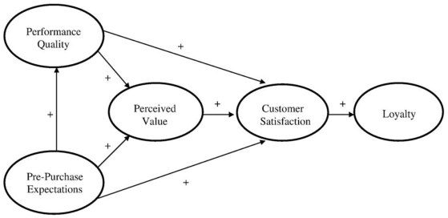

NOTE: figure/graphic rendered as an image from the PDF; its content is not machine-readable text. Caption (if any) follows as the next block.

Fig. 1. Business customer satisfaction: hypothesized relationships.

Page 4

2. A supplier that you have been purchasing from during the course of their downsizing. In other words, you began purchasing from this supplier before it began downsizing and you are still purchasing from this supplier. 3. A supplier you have either primary or shared purchasing responsibility for at your firm. 4. A supplier whose products and/or services are important, but not critical. 5. A supplier who is not a sole source, in other words alternative suppliers for this product/service are available.

Shortly thereafter, the following additional instructions appear:

“In the first two sections of this questionnaire (1) Customer Expectations and (2) Product/Service Quality) we would like to assess how this supplier is currently performing, as compared to your expectations of how this supplier would perform. Therefore, in the first section (1) Customer Expectations) please think back to when you first began purchasing from this supplier and recall your initial expectations. If, however, you began purchasing from this supplier a long time ago (i.e., 3+ years), then please think back to your expectations approximately 1–2 years ago.”

After all of the questions related to pre-purchase expectations are completed, the following instructions appear:

“For the rest of the survey, in each section please indicate how well this supplier is currently performing on the items listed.”

These latter instructions apply to the sections measuring postpurchase performance quality, perceived value, satisfaction, and loyalty. Thus, pre-purchase expectations act as a baseline to which respondents consciously compare their perceptions of subsequent supplier performance and value. In the prior work in B2C markets

described above (e.g., Fornell et al., 1996 — ASCI), pre-purchase expectations are posited and subsequently found to be positively related to post-purchase evaluations of performance quality, perceived value, and overall customer satisfaction. Customer satisfaction, in turn, is predicted and found to be positively related to loyalty (see Fig. 1). Therefore, in accordance to these prior findings and building from theoretical support, the study proposes and tests the following hypotheses to assess these relationships in B2B contexts.

H1. Pre-purchase expectations relate positively to post-purchase (a) perceived performance quality, (b) perceived value, and (c) satisfaction.

H2. Perceived performance quality relates positively to (a) perceived value and (b) satisfaction.

H3. Perceive value relates positively to satisfaction.

H4. Satisfaction relates positively to loyalty.

Nothing within either Hall's (1976) cultural context paradigm or Hofstede's (1980) cultural factors paradigm suggests that prepurchase expectations should vary across purchasing professionals from divergent cultures.

H5. When comparing U.S. versus European samples no significant differences occur in purchasing professionals' pre-purchase expectations of supplier performance.

The remaining hypotheses, offered below, focus on the influence downsizing and culture may have on the proposed modeled relationships.

Table 1 Examples of extant customer satisfaction models.

| B-2-B marketing | Currentstudy | Lam et al 2004 ., | Bowman and Narayandas, 2004 | Cronin and Morris, 1989 |  |  |
| --- | --- | --- | --- | --- | --- | --- |
| literature |  |  |  |  |  |  |
| Competitorefforts |  |  | x |  |  |  |
| Expectations | x |  |  | x |  |  |
| Performance/quality | x |  | x | x |  |  |
| Value | x | x |  |  |  |  |
| Satisfaction | x | x | x |  |  |  |
| Loyalty/repurchase | x | x |  | x |  |  |
| intention |  |  |  |  |  |  |
| B-2-C marketing | Vilares and Coelho, | Bolton and Lemon, | Mittal et al 1998 ., | Fornell et al (ASCI) . , | Tse and Wilton, 1988 | Oliver, 1980 |
| literature | 2003 | 1999 |  | 1996 |  |  |
| Providerimage | x |  |  |  |  |  |
| Expectations | x | x | x | x | x | x |
| Performance/quality | x | x | x | x | x | x |
| Value/paymentequity | x | x |  | x |  |  |
| Satisfaction | x | x | x | x | x | x |
| Customercomplaints |  |  |  | x |  |  |
| Loyalty/repurchase | x |  | x | x |  | x |
| intention |  |  |  |  |  |  |
| Relationshipmarketing | Madaleno et al 2007 ., | Xu et al 2006 ., | Auh and Shih 2005 . | Homburg et al 2003 ., | Cannon and Perreault 1999 , | Andersonand |
| literature |  |  |  |  |  | Narus, 1984 |
| Dependenceon |  |  | x |  | x | x |
| supplier |  |  |  |  |  |  |
| Product/service | x | x | x |  |  |  |
| quality |  |  |  |  |  |  |
| Priceequity(value) | x |  | x |  |  |  |
| Relationshipqualitya | x | x | x | x | x | x |
| Overallexchange | x | x | x | x | x | x |
| satisfaction |  |  |  |  |  |  |
| Repurchaseintention |  | x | x | x |  |  |

NOTE: table converted from PDF layout to HTML text; cell boundaries are reconstructed. See PDF if exact alignment matters.

a Relationship quality has been conceptualized based on a number of constructs including: trust, commitment, cooperation, information exchange, adaptation by seller/buyer, legal bonds, operational linkages, flexibility, special benefits.

Page 5

3.3. Post-purchase performance quality

Market demands lead many suppliers to bundle additional services with their product offerings, often resulting in the need for greater interaction between customers and supplier personnel (Oliva and Sterman, 2001). As part of the supplier selection process, purchasing professionals develop expectations about the future performance of these bundled offerings (an excellent examination of this topic is found in Wilson et al., 2001). Typically in business markets ancillary services are delivered by a variety of functional areas within the supplier firm, including salespeople, customer support personnel, and technical experts. A supplier's inability to meet or exceed buyers' service-related expectations can result from a variety of causes, including the composition and behavior of the supplier's sales and customer support personnel (Estelami and Hurley, 2003; Homburg and Stock, 2004).

However, one of the frequent results of organizational downsizing is the loss of experienced key contact personnel who provide many of the ancillary services customers are promised (Heskett et al., 1994; Kamakura et al., 2002). Additionally, survivors (those employees remaining after downsizing) often lack the requisite time, skill, and/or motivation to provide the quality service customers expect (Nixon et al., 2004). When this is the case, downsized suppliers' service performance often fails to meet customer pre-purchase expectations.

H6a. Professional purchasers' post-purchase evaluations of downsized suppliers' performance quality are lower than their pre-purchase expectations.

Bolton and Myers (2006) observe that business customers from different cultures are likely to hold different perceptions of what constitutes inferior, adequate, or superior performance/quality. Separately, Laroche et al. (2004) argue that culture differentially affects customers' perceptions of service quality; such that high-context, collectivist cultures are more conservative in their assessment of superior quality and less critical in their assessment of inferior quality.

H6b. When comparing U.S. versus European samples, significant differences occur in purchasing professionals' evaluations of downsized supplier performance quality.

3.4. Perceived value

Most agree that satisfaction is significantly influenced by customers' perceptions of the value they receive (Lam et al., 2004). Perhaps the most prominent theoretical discussion of the distinction between and the importance of quality and value in customers' decision making is offered by Zeithaml's (1988) Means End Model. In accordance with this Model, product attributes such as price, reliability, and adherence to specifications influence customers' perceptions of value. Additionally, customers' interactions with suppliers' service-support personnel also influence perceptions of value. In B2B contexts, the relative influence of service-related attributes may be significantly stronger than the influence of product-related attributes on assessments of value (Humphreys and Williams, 1996).

Satisfied, committed, and productive service-support employees create the service components of value (Heskett et al., 1994; Vilares and Coelho, 2003). However, in firms that have downsized, managers frequently attempt to overcome staff reductions in service-support personnel by expecting survivors to work harder. One method survivors use to cope with these increased expectations is by reducing the amount of time they spend with each customer (Oliva and Sterman, 2001). However, perceptions of value decrease when customers feel rushed, or perceive service-support personnel lack the motivation and/or skills required to satisfy their needs.

H7a. Professional purchasers' post-purchase evaluations of value received from downsized suppliers are lower than their pre-purchase expectations.

When one considers the potential influence of culture on business customers' perceptions of value, differing assessments of performance quality as argued in the preceding section likely will have similar affects on value assessments. For example, if culture is expected to influence business customers' assessment of performance quality (i.e., Bolton and Myers, 2006), then perceptions of inferior/superior quality should similarly influence perceptions of inferior/superior value; all else equal. When this is the case, high-context, collectivist cultures will be more conservative in their assessment of value both in inferior and superior quality contexts.

H7b. When comparing U.S. versus European samples, significant differences occur in purchasing professionals' evaluations of value received from downsized suppliers.

3.5. Customer satisfaction and loyalty

This work conceptualizes customer satisfaction as a business customer's evaluation of a supplier's cumulative performance, over time, on product/service attributes (Homburg and Stock, 2004; Spreng et al., 1996). In sum, the literature on cumulative satisfaction suggests that the most important antecedents of satisfaction include past, current, and future customer expectations, current levels of product/service quality, and customers' perceptions of value received (Fornell et al.,1996; Oliver,1980; Zeithaml,1988). This is in contrast to a transaction-specific perspective where customer satisfaction is viewed as a post-purchase evaluative judgment of a specific purchase occasion (Anderson et al., 1994).

Fornell et al. (1996, p. 8) posit that by measuring not only customer satisfaction, but also its antecedents (prior expectations, perceived levels of current performance, and value received) one captures a cumulative evaluation of a firm's market offering over time, as opposed to a buyer's evaluation of a specific transaction. This is important because, “… while transaction specific satisfaction measures may provide specific diagnostic information about a particular product or service encounter, overall customer satisfaction is a more fundamental indicator of the firm's past, current, and future performance.” The findings in a number of studies support these linkages (e.g., Anderson et al., 1994; Lam et al., 2004).

Similarly, a significant body of work supports the view that customer satisfaction is an important antecedent of customer loyalty (e.g., Homburg et al., 2003; Lam et al., 2004). Oliver (1993) proposes that loyalty is developed through a multi-dimensional process wherein varying forms of loyalty can emerge at each step of the process. Oliver (1993) further argues that satisfaction is a fairly temporal state reflecting how the product or service fulfills its purpose based on either a one-time consumption situation or a repeat/ongoing consumption experience. Loyalty, in contrast, is an attained state of more enduring preference. Interestingly, Oliver (1993) further argues that ultimate loyalty is supported not only by product performance, but also by the convergence of personal and social forces — like those this work suggests. Empirical works supporting these relationships include Fornell et al. (1996), Bolton (1998), and Kumar (2002).

Based on the above discussion of customer satisfaction and loyalty coupled with the preceding arguments on performance quality and value, downsized suppliers who are providing lower levels of quality and value will engender lower levels of satisfaction and loyalty among their business customers.

H8. Professional purchasers' post-purchase satisfaction levels with downsized suppliers are lower than their (a) pre-purchase

Page 6

expectations, (b) evaluations of performance quality, and (c) evaluations of value received.

H9. Professional purchasers' levels of loyalty toward downsized suppliers are roughly equal to their level of satisfaction with these suppliers.

According to Hall (1976), in high-context cultures maintaining harmonious, long-term relationships is a high-priority. Thus, business buyers are more likely to give suppliers the benefit-of-the-doubt in cases of performance failures in an effort to maintain harmony in the relationship. As such, purchasers from high-context, collectivist cultures are expected to express higher levels of satisfaction with suppliers (Laroche et al., 2004), and express greater loyalty to their current supplier relationships (Bolton and Myers, 2006).

H10a. When comparing U.S. versus European samples, significant differences occur in purchasing professionals' expressions of satisfaction with downsized suppliers.

H10b. When comparing U.S. versus European samples, significant differences occur in purchasing professionals' expressions of loyalty to downsized suppliers.

4. Control variables

Within social science research the possibility of confounding due to extraneous influence exists. To help minimize potential biases three control variables are included in this study: (1) supplier sales and customer-support staff reductions, (2) the degree/percentage of supplier firm downsizing, and (3) the degree/percentage of buyer firm downsizing.

4.1. Supplier sales and customer-support staff reductions

This work proposes that downsized suppliers' inability to satisfy business customers often results from reductions in sales and customer service-support personnel (Bendapudi and Leone, 2002; Estelami and Hurley, 2003; Heskett et al., 1994; Homburg and Stock, 2004; Oliva and Sterman, 2001). To ensure that reductions in sales and customer-support personnel are included in the analysis, four scaleresponse questions specifically related to staff reductions in these key areas are included in the questionnaire.

4.2. Supplier firm's degree of downsizing

Downsizing announcements generally include information regarding the level of the intended reduction (i.e., the number or percentage of employees to be terminated). Prior work in this area establishes that the degree of downsizing effects survivors' reactions and attitudes, as well as subsequent firm performance (De Meuse et al., 2004; Lewin, 2001; Nixon et al., 2004). To measure the degree to which the focal supplier firm has downsized two questions are included. The range of supplier downsizing reported is between 1% (n=1) and 50% (n=21), with the average being 15.5%.

4.3. Buyer firm's degree of downsizing

During the pretest phase of this study (see Methodology section) the issue of the potential for respondent downsizing bias emerged. That is, if the respondent's (buyer) firm has downsized might that experience positively/negatively predispose respondents to evaluate downsized suppliers differently. As a result of these concerns, respondents are asked (1) if their firm has downsized and (2) if so, about how much. All but two of the total 435 respondents provided responses to these questions. Of these 34.4% reported that their firms have not downsized. The remaining 65.6% indicated that their firms

have downsized between 1% (n=3) and 60% (n=9), with the average being 14.2%.

5. Research method

5.1. Questionnaire development

In all butone case (loyalty) the items used to measure the constructs of interest in this study are adopted from prior empirical works. A measurement items list, including sources, is available through the lead author. After the initial questionnaire was developed a series of three pretests wereundertaken.First,theresearchcoordinatormet withagroup of 11 purchasing professionals to review the questionnaire thoroughly. One key focus area during this meeting was to ascertain the ability of purchasing professionals to accurately report on the nature and extent of supplier downsizing. The consensus among participants was that the majority of purchasing professionals are able to provide this information. Suggestions for improvements made during this initial pretest were used torevise the questionnaire.Next, fourmarketing academicians were asked to review the revised questionnaire to further assess the clarity of the instructions and questions, and to eliminate any potential biasing elements or statements. Further revisions were made based on this second set of reviews. Finally, the questionnaire was mailed to six members of the Institute for Supply Management (ISM) for additional scrutiny. Each of these questionnaires was returned, with only minor suggestions for improvement. Lastly, once the English version of the questionnaire was finalized the Dutch and French versions were created by co-researchers fluent in these two languages. Subsequent pretests of the questionnaire among Dutch and French professionals indicated that the original intent and measurement remained consistent.

5.2. Research context and data collection

Countries with mature economies where supplier downsizing occurred on a regular basis during recent years are required for this study. The Netherlands and France represent mature economies that are similar to the U.S. economy, while they are at the same time culturally different. The Netherlands and France are examples of relatively high-context, collectivist cultures, thus providing a contrast to the more low-context, individualist culture in the U.S. This allows us to explore the extent to which a country's cultural context influences the impact of supplier downsizing on customer satisfaction.

The respondents in the U.S. represent a random sample of purchasing professionals drawn from the membership of ISM. Similar organizations in The Netherlands and France provide the sampling frame for European purchasers. Cannon and Perreault (1999) point out that while others within the buying firm may have knowledge of some aspects of a supplier relationship,purchasingprofessionalsarewell-informedaboutallaspects of the overall relationship. This makes purchasing professionals the best choice of key informant in studies like the one reported here. Many other researchers in this stream support this belief (e.g., Buvik, 2002; Hutt et al., 1985; Puri and Korgaonkar, 1981). In all, 1346 packets were mailed to potential respondents in the U.S., and 3800 packets were mailed to respondents in Europe. Each packet contained a questionnaire, a cover letter, and a postage-prepaid return envelope. As a result of the initial and subsequent follow-up efforts, 266 usable questionnaires were received from U.S. respondents (19.8%), and 169 usable questionnaires were received from European respondents (4.4%). Admittedly, a stronger response rate from the European effort was anticipated. Nevertheless, as pointed out by several researchers (e.g., Harzing, 2000; Ibeh et al., 2004), response rates in survey research continue to shrink; especially among European industrial populations. Further, as Hunt (1990, p. 174) convincingly argues, “No manuscript should be rejected on the basis of potential nonresponse bias–no matter what the response rate is–unless there is good reason to believe that the respondents do in fact differ from the nonrespondents on the

Page 7

substantive issues in question and that these differences would make the results of the study unreliable.” Notwithstanding these issues, response bias is assessed by comparing early versus late response across study variables; with no significant differences found. Also, the questionnaire contains four items designed to assess respondents' ability to provide reliable information. Based on a 10-point scale, the mean level of ability across all 435 respondents is 8.60 (std. dev. 1.00) — indicating respondents are well qualified to report on their focal downsized supplier.

Finally, key demographics indicate that respondents and their respective companies are quite diverse. For example, the size of companies based on annual sales range from small (b$25,000,000), to medium ($25,000,000–$99,000,000), to quite large (N$500,000,000). Industries represented include manufacturing, telecommunication, business services, transportation, utilities, non-profit, government, retail, construction, and more. Withregard to respondents,job positions include buyers, purchasing agents, purchasing managers, purchasing directors, and purchasing vice presidents. In sum, the diversity of the respondents and their companies suggests that the samples are quite robust; thus, findings likely will be generalizable to the larger focal population.

5.3. Measurement validation procedure

First, each set of items is examined using item-to-total correlations to segregate items poorly fitted to specific construct domains. Second,

the resulting sets of items are analyzed via confirmatory factor analysis using LISREL 8.5 to verify unidimensionality. The following fit statistics indicate an acceptable fit (Hu and Bentler, 1999) for both samples (U.S.: CFI=.98, NFI=.95, SRMR=.06, RMSEA=.05; European: CFI=.97, NFI=.89, SRMR=.05, RMSEA=.04).

Third, composite reliabilities are calculated and the average variance extracted (AVE) of each construct is assessed (Fornell and Larcker, 1981). Across both samples, all of the factor loadings are significant, and composite reliabilities range from .84 to .97. The AVEs range from .51 to .87; above the recommended .50 level (Fornell and Larcker, 1981). Fourth, discriminant validity is assessed by estimating a series of two-factor confirmatory models. For each pair the model is estimated first by restricting the factor intercorrelations to unity. Then the model is estimated again with the restriction removed. In each case, the chi-square difference tests (1 df) are significantly smaller in the unrestricted model demonstrating discriminant validity.

6. Results

6.1. Applying the ASCI model in B2B contexts

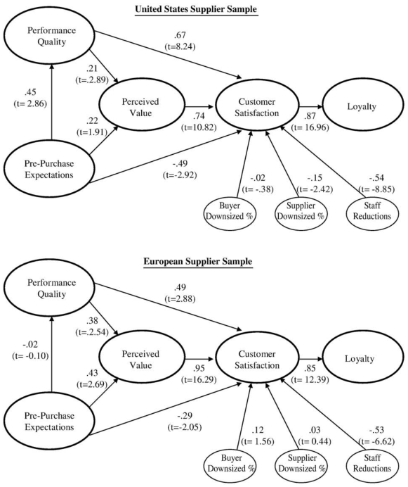

NOTE: figure/graphic rendered as an image from the PDF; its content is not machine-readable text. Caption (if any) follows as the next block.

Fig. 2. Business customer satisfaction.

Page 8

6.2. Assessment of control variables

While no control variable hypotheses are offered, the results of including these variables in the model are summarized as follows. As shown in Fig. 2, in both samples a significant, negative relationship is found between reductions in sales and customer-support personnel and business customers' satisfaction with downsized suppliers — as expected. With regard to the relationship between the degree (percent) of suppliers' downsizing and satisfaction the same significant, negative effect is found in the U.S. sample. However in the European sample this relationship is not statistically significant. Lastly, the degree (percent) of downsizing by the respondent's firm is not significant

in either sample; suggesting concerns related to potential respondent bias are not supported.

6.3. Business customers' satisfaction with downsized suppliers

Mean differences are assessed (LISREL 8.5) to evaluate the relationships among expectations, performance quality, value, satisfaction, and loyalty with downsized suppliers; first using the combined U.S. and European samples (n=435) and then using the segregated samples individually. As shown inTable 3a footnote b, only two minor differences in the results are found when comparing the combined sample to the segregated samples. Therefore, the following discussion is limited to the combined sample results.

As predicted, post-purchase evaluations of the performance quality of downsized suppliers (H6a) and value received from downsized suppliers (H7a) are both lower than their pre-purchase expectations. Similarly, purchasers' post-purchase satisfaction levels with downsized suppliers are lower than their pre-purchase expectations (H8a), as well as lower than their post-purchase evaluations of performance quality (H8b) and value received (H8c). Also as predicted, purchasers' expression of loyalty toward their downsized suppliers is roughly equal to their satisfaction with these suppliers (t-value=0.31). Thus, support is found for each of these proposed hypotheses. In sum, these findings indicate that downsized suppliers are, in general, not doing a very good job of satisfying their business customers.

6.4. Cultural differences in satisfaction with downsized suppliers

SEM multi-group analysis (LISREL 8.5) is used to test the hypotheses related to potential cultural differences across the

Table 3b Comparisons of group means.

[output not shown]

NOTE: table converted from PDF layout to HTML text; cell boundaries are reconstructed. See PDF if exact alignment matters.

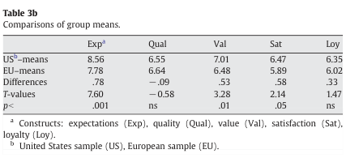

NOTE: figure/graphic rendered as an image from the PDF; its content is not machine-readable text. Caption (if any) follows as the next block.

**text found inside the figure**

a Constructs: expectations (Exp), quality (Qual), value (Val), satisfaction (Sat), loyalty (Loy).

b United States sample (US), European sample (EU).

Table 3a Comparisons of construct means<sup>a</sup><sup>,</sup><sup>b</sup>.

[output not shown]

NOTE: table converted from PDF layout to HTML text; cell boundaries are reconstructed. See PDF if exact alignment matters.

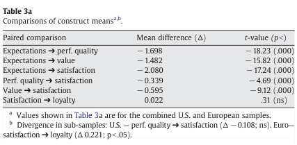

NOTE: figure/graphic rendered as an image from the PDF; its content is not machine-readable text. Caption (if any) follows as the next block.

**text found inside the figure**

a Values shown in Table 3a are for the combined U.S. and European samples. b Divergence in sub-samples: U.S. — perf. quality ➔satisfaction (Δ −0.108; ns). Euro— satisfaction ➔loyalty (Δ 0.221; pb.05).

Table 2 Results of hypotheses tests.

|  | Statedhypotheses | Support |
| --- | --- | --- |
| H1 | Pre-purchase expectations will be positively related to post-purchase (a) perceived performance quality, (b) perceived value, and (c) satisfaction. | (a)Partial;US |
|  |  | (b)Partial;Euro |
|  |  | (c)No;opposite |
| H2 | Perceived performance quality will be positively related to (a) perceived value and (b) satisfaction. | (a)Yes |
|  |  | (b)Yes |
| H3 | Perceive value will be positively related to satisfaction. | Yes |
| H4 | Satisfaction will be positively related to loyalty. | Yes |
| H5 | When comparing U .S . versus European samples, no significant differences are expected in purchasing professionals' pre-purchase expectations of | No |
|  | supplier performance. |  |
| H6a | Professional purchasers' post-purchase evaluations of downsized suppliers' performance quality will be lower than their pre-purchase expectations. | Yes |
| H6b | When comparing U .S . versus European samples, significant differences are expected in purchasing professionals' evaluations of downsized supplier | No |
|  | performance quality. |  |
| H7a | Professional purchasers' post-purchase evaluations of value received from downsized suppliers will be lower than their pre-purchase expectations. | Yes |
| H7b | When comparing U .S . versus European samples, significant differences are expected in purchasing professionals' evaluations of value received from | Yes |
|  | downsized suppliers. |  |
| H8 | Professional purchasers' post-purchase satisfaction levels with downsized suppliers will be lower than their (a) pre-purchase expectations, | (a)Yes |
|  | (b) evaluations of performance quality, and (c) evaluations of value received . | (b)Yes |
|  |  | (c)Yes |
| H9 | Professional purchasers' levels of loyalty toward downsized suppliers will be roughly equal to their level of satisfaction with these suppliers. | Yes |
| H10a | When comparing U .S . versus European samples, significant differences are expected in purchasing professionals' expressions of satisfaction with downsized suppliers. | Yes |
| H10b | When comparing U .S . versus European samples, significant differences are expected in purchasing professionals' expressions of loyalty to downsized suppliers. | No |

NOTE: table converted from PDF layout to HTML text; cell boundaries are reconstructed. See PDF if exact alignment matters.

Page 9

modeled relationships. Examining the construct mean differences and associated t-values across the two groups identifies where the significant differences occur (see Table 3b). Hypothesis H5 predicts no significant difference between the two groups in their prepurchase expectations of supplier performance. On a 10-point scale where 10=very high expectations the mean level response was 8.56 (U.S.) and 7.78 (European). While both mean level responses are fairly high, the difference between the two is statistically significant (pb.001); thus failing to support H5.

The subsequent cultural hypotheses predict significant differences in mean responses across the two groups with regard to evaluations of downsized suppliers' performance quality (H6b), perceived value (H7b), satisfaction (H10a) and loyalty (H10b). Statistical support for these four hypotheses is mixed. Support is found for differences in evaluations of value (pb.01) and levels of satisfaction (pb.05) with downsized suppliers. As expected, European purchasers' evaluations of value are more conservative than their U.S. counterparts. However, contrary to expectations, their levels of satisfaction also are more conservative. Finally, no support is found for differences in evaluations of performance quality and levels of loyalty.

7. Implications

First, with regard to the applicability of the ASCI model in several B2B contexts, the significant negative relationship between prepurchase expectations and customer satisfaction in both the U.S. and European samples is surprising. Two possible alternative explanations may support these unexpected findings. First, purchasers are asked to report their pre-purchase expectations prior to supplier downsizing. Then, purchasers are asked to report their evaluations of performance quality, value, and satisfaction after supplier downsizing. Through this process, the disconfirmation of pre-purchase expectations leads to the negative relationship between pre-downsizing expectations and postdownsizing satisfaction. In other words, the higher a purchaser's expectations prior to supplier downsizing, the more difficulty the supplier has in meeting those high-level expectations after downsizing. This implies the higher the expectations the greater the disappointment. However, this does not explain why findings indicate a positive relationship between pre-purchase expectations and evaluations of performance quality and value (e.g., higher expectations lead to higher evaluations of quality and value). One would expect if negative disconfirmation occurs, then lower-than-expected satisfaction would stem directly from lower-than-expected performance quality and value. Thus similar negative relationships are expected. However, this is not the case here. A second alternative possibility is that during the supplier selection process professional purchasers, in their effort to select the best supplier, develop excessively high pre-purchase expectations; more so than may be the case among consumers. As a result, the higher the pre-purchase expectation the more difficulty suppliers have in meeting or exceeding these very high expectations. However, as before, this does not explain the positive relationships between pre-purchase expectations and post-purchase evaluations of performance quality and value. Thus, at least this component of the ASCI model's applicability in B2B contexts remains questionable.

Second, study findings indicate that business customers (both U.S. and European) enter into their focal buyer–supplier relationships with relatively high expectations of anticipated supplier performance (8.56 and 7.78, respectively). In this study this finding sets a baseline for comparison of subsequent performance. Against this baseline of comparison downsized suppliers fail to meet buyers' performance expectations. In both samples post-purchase evaluations of downsized supplier performance quality, value received, overall satisfaction, and loyalty are all significantly below pre-downsizing expectations. Furthermore, the link between downsizing and performance disappointment is strengthened by the finding that reductions in suppliers' sales and

customer-support staff has a relatively strong, negative impact on customer satisfaction in both samples. Thus, study findings add strength to the emerging belief that downsizing can have substantial, long-term deleterious effects.

7.1. Managerial implications

This study provides empirical evidence of the impact reductions in sales and customer-support personnel have on business customers' satisfactionwith and loyalty toward downsized suppliers. Together with recent findings in the finance and management literatures, study results provide ample motivation for downsizing proponents to reevaluate this prevalent strategy. This reasoning is further strengthened by beliefs that small changes in customer satisfaction levels can significantly influence a firm's profitability, cash flow, and market equity (Fornell et al., 1996; Fornell et al. 2006; Reichheld and Sasser, 1990).

When downsizing must occur, the results of this research suggest several implications for future downsizing organizations. First, while most agree that customer satisfaction should be monitored regularly, the findings reported here indicate the need for satisfaction monitoring is significantly greater for firms that downsize their workforce, especially key contact personnel. Second, these study findings coupled with other research (De Meuse et al., 2004; Nixon et al., 2004) suggest that smaller, more strategic downsizing (i.e., minimize eliminating key contact personnel) appears to have less impact on satisfaction and loyalty. Third, in those cases where large broad-based cuts are judged advisable, proactive strategies should be developed to minimize the negative effects on both customer and survivor satisfaction — since the literature indicates that satisfaction levels between these two groups are strongly interrelated (Bendapudi and Leone, 2002; Estelami and Hurley, 2003; Homburg and Stock, 2004).

8. Research limitations and directions for future research

This study is exploratory in nature. Thus, the study implications are tentative. Also, the assumption is made that purchasing professionals, as key informants, are able to provide reliable information on the focal constructs. This assumption is tested using questions designed to assess respondents' ability to provide meaningful information. Finally, firms represented by respondents in the US sample are weighted more heavily (49.3%) toward larger firms (i.e., revenues exceed $500 million).

Future work in this area might examine if various catalysts to downsizing have (dis)similar outcomes, especially with relation to customer satisfaction and loyalty. A second area of investigation might question what, if any, compensatory adjustments downsized firms should initiate to minimize the negative impact of downsizing on customer satisfaction. Finally, comparisons of business customers' levels of satisfaction with downsized verses non-downsized suppliers may provide a more accurate assessment of the degree to which satisfaction levels across these two groups of suppliers differ.

Page 10

References

Anderson EW, Fornell C, Lehmann DR. Customer satisfaction, market share, and

profitability: findings from Sweden. J Mark 1994;58(2):53–66. Anderson EW, Fornell C, Rust RT. Customer satisfaction, productivity, and profitability:

differences between goods and services. Mark Sci 1997;16(2):129–46. Anderson JC, Narus JA. A model of the distributor's perspective of distributor–

manufacturer working relationships. J Mark 1984;48(4):62–74. Auh S, Shih CF. The relative effects of relationship quality and exchange satisfaction on

customer loyalty. J Bus -Bus Mark 2005;12(2):73–97. Bendapudi N, Leone RP. Managing business-to-business customer relationships following

key contact employee turnover in a vendor firm. J Mark 2002;66(2l):83-101. Beverland M, Napoli J, Lindgreen A. Industrial global brand leadership: a capabilities

view. Ind Mark Manage 2007;36(8):1082–93. Bolton RN. A dynamic model of the duration of the customer's relationship with a

continuous service provider: the role of satisfaction. Mark Sci 1998;17(1):45–66. Bolton RN, Lemon KN. A dynamic model of customers' usage of services: usage as an

antecedent and consequence of satisfaction. J Mark Res 1999;36(2):171–86. Bolton RN, Myers MB. Priced-based global market segmentation for services. J Mark

2006;67(3):108–28. Bolton RN, Smith AK, Wagner J. Striking the right balance. J Serv Res 2003;5(2):271–91. Bowman D, Narayandas D. Linking customer management effort to customer profit-

ability in business markets. J Mark Res 2004;41(4):433–47. Brockner J. The effects of work layoffs on survivors: research, theory, and practice. Res

Organ Behav 1988;10(1):213–48. Bryant BE. Bad vibes. Mark Tools 1997;4(9):9-10. Bureau of Labor Statistics Data. U.S. Department of Labor; 2005. www.bls.gov. Burton J, Mitchell T, Lee T. The role of self-esteem and social influences in aggressive

reactions to interactional justice. J Bus Psychol 2005;20(1):131–70. Buvik A. Manufacturer-specific asset investments and inter-firm governance forms: an

empirical test of the contingent effect of exchange frequency. J Bus -Bus Mark 2002;9(4):3-26. Cannon JP, Perreault WD. Buyer–seller relationships in business markets. J Mark Res

1999;36(4):439–60. Cascio WF, Young CE, Morris JR. Financial consequences of employment-change

decisions in major U.S. corporations. Acad Manage J 1997;40(5):1175–89. Churchill GA, Surprenant C. An investigation into the determinants of customer

satisfaction. J Mark Res 1982;19(4):491–504. Cronin JJ, Morris MH. Satisfying customerexpectations: the effects on conflict and repurchase

intentions in industrial marketing channels. J Acad Mark Sci 1989;17(1):41–9. CNNMoney. Citigroup to hack 17,000 jobs; 2007. www.CNNMoney.com April 10. De Meuse KP, Bergmann TJ, Vanderheiden PA, Roraff CE. New evidence regarding

organizational downsizing and a firm's financial performance: a long-term analysis. J Manag Issue 2004;16(3):155–77. Doney PM, Cannon JP. An examination of the nature of trust in buyer–seller relationships. J

Mark 1997;61(2):35–51. Edwards R, Gut AM, Mavondo F. Buyer animosity in business to business markets:

evidence from the French nuclear tests. Ind Mark Manage 2007;36(4):483–92. Ennew CT, Ahmed N. Managing word of mouth communication. In: McAuley A, Sparks

L, editors. Proceedings of the Annual Conference. Academy of Marketing; 1999. Estelami H, Hurley RF. Does employee turnover predict customer satisfaction? vol. 4

(03–121) Marketing Science Institute Working Paper Series; 2003. p. 41–56. 2003. Ferraro F, Pfeffer J, Sutton RI. Economics language and assumptions: how theories can

become self-fulfilling. Acad Manage Rev 2005;30(1):8-26. Fornell C, Larcker DF. Evaluating structural equation models with unobservable

variables and measurement error. J Mark Res 1981;18(1):39–50 1981. Fornell C, Johnson MD, Anderson EW, Cha J, Bryant BE. The American customer

satisfaction index: nature, purpose, and findings. J Mark 1996;60(4):7-18. Fornell C, Mithas S, Morgeson FV, Krishnan MS. Customer satisfaction and stock prices:

high returns, low risk. J Mark 2006;70(1):3-14. Gwinner KP, Gremler DD, Bitner MJ. Relational benefits in service industries: the

customer's perspective. J Acad Mark Sci 1998;26(2):101–14. http://changingminds.org/explanations/culture/hall_culture.htm; 2009. http://www.via-web.de/273.html; 2009. Hall ET. Beyond culture. Garden City, NY: Doubleday; 1976. Harzing AW. Cross-national industrial mail surveys: why do response rates differ

between countries? Ind Mark Manage 2000;29(2):243–54. Heskett JL, Jones TO, Loveman GW, Sasser WE, Schlesinger LA. Putting the service profit

chain to work. Harvard Bus Rev 1994;72(2l):164–74. Hodson R, Roscigno VJ. Organizational success and worker dignity: complementary or

contradictory? Am J Sociol 2004;110(3):672–708. Hofstede G. Culture's consequences: international differences in work-related values.

Beverly Hills, CA: Sage Publications; 1980. Homburg C, Rudolph B. Customer satisfaction in industrial markets: dimensional and

multiple role issues. J Bus Res 2001;52(1):15–33. Homburg C, Stock RM. The link between salespeople's job satisfaction and customer

satisfaction in a business-to-business context: a dyadic analysis. J Acad Mark Sci 2004;32(2):144–58.

Homburg C, Giering A, Menon A. Relationship characteristics as moderators of the

satisfaction–loyalty link: findings in a business-to-business context. J Bus -Bus Mark 2003;10(3):35–62. Humphreys MA, Williams MR. Exploring the relative effects of salesperson inter-

personal process attributes and technical product attributes on customer satisfaction. J Pers Sell Sales Manage 1996;16(2):47–57. Hu L, Bentler PM. Cutoff criteria for fit indexes in covariance structure analysis:

conventional criteria versus new alternatives. Struct Eq Modeling 1999;6(1):1-55. Hunt S. Commentary on an empirical investigation of a general theory of marketing

ethics. J Acad Mark Sci 1990;18(2):173–7. Hutt MC, Johnston WJ, Ronchetto JR. Selling centers and buying centers: formulating

strategic exchange patterns. J Pers Sell Sales Manage 1985;5(1):32–40. Ibeh K, Brock JK, Zhou YJ. The drop and collect survey among industrial populations:

theory and empirical evidence. Ind Mark Manage 2004;33(2):155–65. Kamakura WA, Vikas M, De Rosa F, Mazzon JA. Assessing the service-profit chain. Mark

Sci 2002;21(3):294–318. Kumar P. The impact of performance, cost, and competitive considerations on the

relationship between satisfaction and repurchase intentions in business markets. J Serv Res 2002;52(3):55–68. Lam SY, Shankar V, Erramilli MK, Murthy B. Customer value, satisfaction, loyalty, and

switching costs: an illustration from a business-to-business service context. J Acad Mark Sci 2004;32(3):293–311. Laroche M, Ueltschy LC, Abe M, Cleveland O, Yannopoulos P. Service quality perceptions

and customer satisfaction: evaluating the role of culture. J Int Mark 2004;12(3):58–85. Lewin JE. The effects of downsizing on organizational buying behavior: an empirical

examination. J Acad Mark Sci 2001;29(2):151–66. Lewin JE. An empirical investigation of the effects of downsizing on buyer–seller

relationships. J Bus Res 2003;56(4):283–93. Lewin JE, Johnston WJ. The effects of organizational restructuring on industrial buying

behavior: 1990 and beyond. J Bus Ind Mark 1996;11(6):93-111. Liang CJ, Wang WH. Attributes, benefits, customer satisfaction and behavioral loyalty—

an integrative research of financial services industry in Taiwan. J Serv Res 2004;4 (1):57–88. Madaleno R, Wilson H, Palmer R. Determinants of customer satisfaction in a multi-

channel B2B environment. Total Qual Manag 2007;18(8):915–25. Markels A, Murray M. Slashed and burned: call it dumbsizing: why some companies

regret cost-cutting. Wall Str J East Ed 1996;227:95 May 14: A1. McKinley W, Zhao J, Rust K. A socio-cognitive interpretation of organizational

downsizing. Acad Manage Rev 2000;25(1):227–43. Mishra A, Spreitzer G. Explaining how survivors respond to downsizing: the roles of trust,

empowerment, justice, and work redesign. Acad Manage Rev 1998;23(3):567–88. Mittal V, Ross WT, Baldasare PM. The asymmetric impact of negative and positive

attribute-level performance on overall satisfaction and repurchase intentions. J Mark 1998;62(1):33–47. Nixon RD, Hitt MA, Lee HU, Jeong E. Market reactions to announcements of corporate

downsizingactionsandimplementationstrategies.StrategManageJ2004;25(4):1121–9. Oliva R, Sterman JD. Cutting corners and working overtime: quality erosion in the

service industry. Manage Sci 2001;47(3):894–914. Oliver RL. A cognitive model of the antecedents and consequences of satisfaction

decisions. J Mark Res 1980;17(4):460–9. Oliver RL. Whence consumer loyalty? J Mark 1993;63(Special Issue):33–44. Puri SJ, Korgaonkar P. Couple the buying and selling teams. Ind Mark Manage 1981;20

(4):311–7. Reichheld FF, Sasser WE. Zero defections: quality comes to services. Harvard Bus Rev

1990;68(5):105–11. Rokkan AI, Heide JB, Wathne KH. Specific investments in marketing relationships:

expropriation and bonding effects. J Mark Res 2003;40(2):210–24. Rust RT, Zeithaml VA, Lemon K. Driving customer equity. Boston, MA: Free Press; 2000. Scheer LK, Kumar N, Steenkamp JB. Reactions to perceived inequity in U.S. and Dutch

interorganizational relationships. Acad Manage J 2003;46(3):303–16. Spreng RA, MacKenzie SB, Olshavsky RW. A reexamination of the determinants of

consumer satisfaction. J Mark 1996;60(3):15–34 1996. Tse DK, Wilton PC. Models of consumer satisfaction formation: an extension. J Mark Res

1988;25(2):204–12. Veysey S, Miller R. Allianz, RSA to cut nearly 9000 jobs. Bus Insur 2006;40(26):23. Vilares MJ, Coelho PS. The employee–customer satisfaction chain in the ECSI model. Eur

J Mark 2003;37(11/12):1703–22. Wiele TV, Boselie P, Hesselink M. Empirical evidence for the relationship between customer

satisfaction and business performance. Manag Serv Qual 2002;12(3):184–93. Wilson EJ, McMurrian RC, Woodside AG. How buyers frame problems: revisited. Psychol

Mark 2001;18(6):617–55. Xu Y, Goedegebuure R, van der Heijden B. Customer perception, customer satisfaction,

and customer loyalty within Chinese securities business: towards a mediation model for predicting customer behavior. J Relatsh Mark 2006;54(4):79-104. Zeithaml VA. Consumer perceptions of price, quality, and value: a means–end model

and synthesis of evidence. J Mark 1988;52(3):2-22.